# Uber Data Analysis in Python Using Machine Learning

### Step 2: Cleaning the dataset

Removing the unecessary data:

```python
dataset=dataset[:-1]
```

Show all the null values per column:

```python
dataset.isnull().sum()
```

```
START_DATE*      0
END_DATE*        0
CATEGORY*        0
START*           0
STOP*            0
MILES*           0
PURPOSE*       502
dtype: int64
```

Representing these null values in a heatmap:

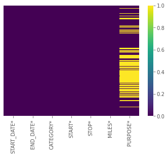

```python
sns.heatmap(dataset.isnull(),yticklabels=False,cmap="viridis")
```

Drop/Remove the null values from the dataset and represent it in a heatmap:

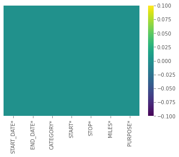

```python
dataset=dataset.dropna()
sns.heatmap(dataset.isnull(),yticklabels=False,cmap="viridis")
```

### Step 3: Transforming the dataset

Assembling a datetime from multiple columns of a DataFrame:

```python
dataset['START_DATE*'] = pd.to_datetime(dataset['START_DATE*'], format="%m/%d/%Y %H:%M")
dataset['END_DATE*'] = pd.to_datetime(dataset['END_DATE*'], format="%m/%d/%Y %H:%M")
```

Getting an hour, day, days of week and a month from the date of trip:

```python
hour=[]
day=[]
dayofweek=[]
month=[]
weekday=[]
for x in dataset['START_DATE*']:
    hour.append(x.hour)
    day.append(x.day)
    dayofweek.append(x.dayofweek)
    month.append(x.month)
    weekday.append(calendar.day_name[dayofweek[-1]])
dataset['HOUR']=hour
dataset['DAY']=day
dataset['DAY_OF_WEEK']=dayofweek
dataset['MONTH']=month
dataset['WEEKDAY']=weekday
```

Find the travelling time using the below method:

```python
time=[]
dataset['TRAVEL_TIME']=dataset['END_DATE*']-dataset['START_DATE*']
for i in dataset['TRAVEL_TIME']:
    time.append(i.seconds/60)
dataset['TRAVEL_TIME']=time
dataset.head()
```

|  | START_DATE* | END_DATE* | CATEGORY* | START* | STOP* | MILES* | PURPOSE* | HOUR | DAY | DAY_OF_WEEK | MONTH | WEEKDAY | TRAVEL_TIME |
| --- | --- | --- | --- | --- | --- | --- | --- | --- | --- | --- | --- | --- | --- |
| 0 | 2016-01-01 21:11:00 | 2016-01-01 21:17:00 | Business | Fort Pierce | Fort Pierce | 5.1 | Meal/Entertain | 21 | 1 | 4 | 1 | Friday | 6.0 |
| 2 | 2016-01-02 20:25:00 | 2016-01-02 20:38:00 | Business | Fort Pierce | Fort Pierce | 4.8 | Errand/Supplies | 20 | 2 | 5 | 1 | Saturday | 13.0 |
| 3 | 2016-01-05 17:31:00 | 2016-01-05 17:45:00 | Business | Fort Pierce | Fort Pierce | 4.7 | Meeting | 17 | 5 | 1 | 1 | Tuesday | 14.0 |
| 4 | 2016-01-06 14:42:00 | 2016-01-06 15:49:00 | Business | Fort Pierce | West Palm Beach | 63.7 | Customer Visit | 14 | 6 | 2 | 1 | Wednesday | 67.0 |
| 5 | 2016-01-06 17:15:00 | 2016-01-06 17:19:00 | Business | West Palm Beach | West Palm Beach | 4.3 | Meal/Entertain | 17 | 6 | 2 | 1 | Wednesday | 4.0 |

Calculate the average speed:

```python
dataset['TRAVEL_TIME']=dataset['TRAVEL_TIME']/60
dataset['SPEED']=dataset['MILES*']/dataset['TRAVEL_TIME']
dataset.head()
```

|  | START_DATE* | END_DATE* | CATEGORY* | START* | STOP* | MILES* | PURPOSE* | HOUR | DAY | DAY_OF_WEEK | MONTH | WEEKDAY | TRAVEL_TIME | SPEED |
| --- | --- | --- | --- | --- | --- | --- | --- | --- | --- | --- | --- | --- | --- | --- |
| 0 | 2016-01-01 21:11:00 | 2016-01-01 21:17:00 | Business | Fort Pierce | Fort Pierce | 5.1 | Meal/Entertain | 21 | 1 | 4 | 1 | Friday | 0.100000 | 51.000000 |
| 2 | 2016-01-02 20:25:00 | 2016-01-02 20:38:00 | Business | Fort Pierce | Fort Pierce | 4.8 | Errand/Supplies | 20 | 2 | 5 | 1 | Saturday | 0.216667 | 22.153846 |
| 3 | 2016-01-05 17:31:00 | 2016-01-05 17:45:00 | Business | Fort Pierce | Fort Pierce | 4.7 | Meeting | 17 | 5 | 1 | 1 | Tuesday | 0.233333 | 20.142857 |
| 4 | 2016-01-06 14:42:00 | 2016-01-06 15:49:00 | Business | Fort Pierce | West Palm Beach | 63.7 | Customer Visit | 14 | 6 | 2 | 1 | Wednesday | 1.116667 | 57.044776 |
| 5 | 2016-01-06 17:15:00 | 2016-01-06 17:19:00 | Business | West Palm Beach | West Palm Beach | 4.3 | Meal/Entertain | 17 | 6 | 2 | 1 | Wednesday | 0.066667 | 64.500000 |

Describe the dataset:

```python
dataset.describe()
```

|  | MILES* | HOUR | DAY | DAY_OF_WEEK | MONTH | TRAVEL_TIME | SPEED |
| --- | --- | --- | --- | --- | --- | --- | --- |
| count | 653.000000 | 653.00000 | 653.000000 | 653.000000 | 653.000000 | 653.000000 | 653.000000 |
| mean | 11.196325 | 14.82389 | 15.719755 | 3.027565 | 6.416539 | 0.389969 | 25.261340 |
| std | 22.986429 | 4.81733 | 8.840242 | 1.951680 | 3.973976 | 0.429494 | 16.815108 |
| min | 0.500000 | 0.00000 | 1.000000 | 0.000000 | 1.000000 | 0.033333 | 6.000000 |
| 25% | 3.200000 | 12.00000 | 8.000000 | 1.000000 | 3.000000 | 0.183333 | 16.571429 |
| 50% | 6.400000 | 15.00000 | 16.000000 | 3.000000 | 6.000000 | 0.300000 | 22.285714 |
| 75% | 10.400000 | 18.00000 | 23.000000 | 5.000000 | 11.000000 | 0.466667 | 29.100000 |
| max | 310.300000 | 23.00000 | 31.000000 | 6.000000 | 12.000000 | 5.500000 | 228.000000 |

### Step 4: Visualizing the dataset

Fix the data types of data columns:

```python
def convert_time(column_name):
    y=[]
    for x in dataset[column_name]:
        y.append(datetime.datetime.strptime('1/1/2016 21:11', "%m/%d/%Y %H:%M"))

    dataset[column_name] = y
```

```python
column_date=dataset[['START_DATE*','END_DATE*']]
for x in column_date:
    convert_time(x)
```

Plot the different categories of the trip. Here we observe from the resulting visualization that most trips are made for business category when compared to personal category.

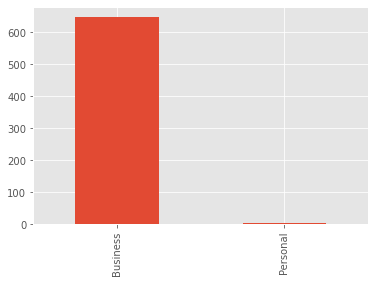

```python
x = dataset['CATEGORY*'].value_counts().plot(kind='bar')
```

Histogram for miles travelled:

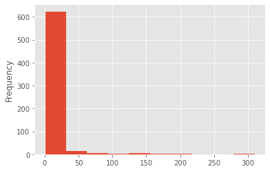

```python
dataset['MILES*'].plot.hist()
```

Plot the purpose of the trip. We observe from the resulting graph that mostly the purpose were for meeting.

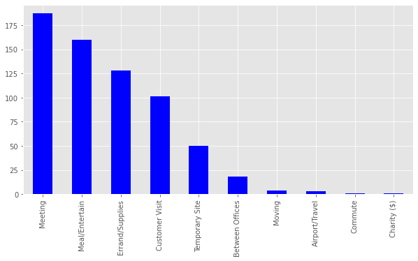

```python
dataset['PURPOSE*'].value_counts().plot(kind='bar',figsize=(10,5),color='blue')
```

Plot the trips per hours in a day:

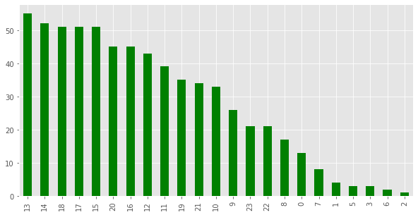

```python
dataset['HOUR'].value_counts().plot(kind='bar',figsize=(10,5),color='green')
```

Plot the trips per day of the week. Most of the trips are on Friday.

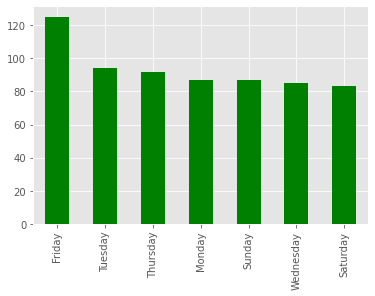

```python
dataset['WEEKDAY'].value_counts().plot(kind='bar',color='green')
```

Plot the trips per day in a month:

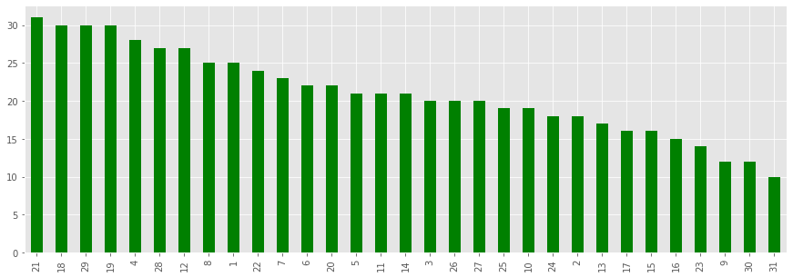

```python
dataset['DAY'].value_counts().plot(kind='bar',figsize=(15,5),color='green')
```

Plot the trips carried out in a month:

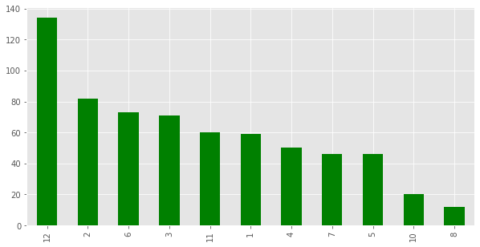

```python
dataset['MONTH'].value_counts().plot(kind='bar',figsize=(10,5),color='green')
```

Ploting the starting point of the trip. Most of them are hiring from Cary.

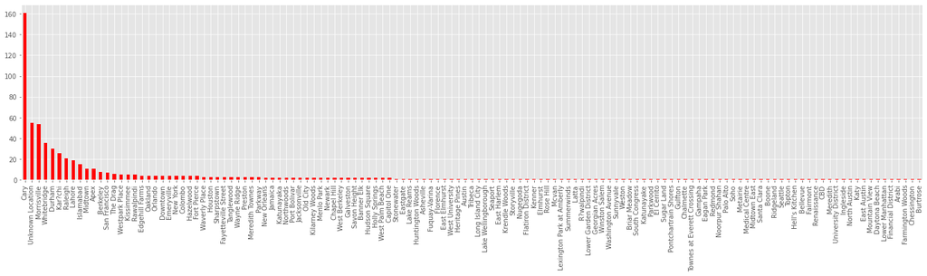

```python
dataset['START*'].value_counts().plot(kind='bar',figsize=(25,5),color='red')
```

Comparing the overall purpose with miles, hour, day of week, month, travel time and speed.

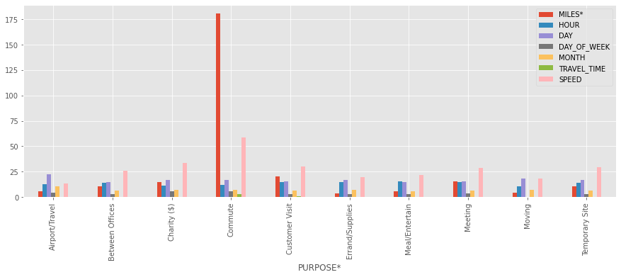

```python
dataset.groupby('PURPOSE*').mean().plot(kind='bar',figsize=(15,5))
```

### Summary

In this project, I have aimed to expose all the interesting insights that can be derived from a detailed analysis of the dataset. The aim of this project was to visualize Uber's ridership growth by ploting them. There are different types of graphical representations used. They are, [histogram](https://www.geeksforgeeks.org/numpy-histogram-method-in-python/), [bar plot](https://www.geeksforgeeks.org/bar-plot-in-matplotlib/) and [heatmap](https://www.geeksforgeeks.org/ml-matrix-plots-in-seaborn/). We have made use of packages like ggplot that allowed us to plot various types of data visualization.